# Travel Package Purchase Prediction - Solution

### Background and Context

A tourism company named "Visit with us" wants to enable and establish a viable business model to expand the customer base.

A viable business model is a central concept that helps you to understand the existing ways of doing the business and how to change the ways for the benefit of the tourism sector.

One of the ways to expand the customer base is to introduce a new offering of packages.

Currently, there are 5 types of packages the company is offering - Basic, Standard, Deluxe, Super Deluxe, King. Looking at the data of the last year, we observed that 18% of the customers purchased the packages.

However, it was difficult to identify the potential customers because customers were contacted at random without looking at the available information.

The company is now planning to launch a new product i.e. Wellness Tourism Package. Wellness Tourism is defined as Travel that allows the traveler to maintain, enhance or kick-start a healthy lifestyle, and support or increase one's sense of well-being.

This time company wants to harness the available data of existing and potential customers to target the right customers.

As a data scientist the idea is to analyze the customers' data and information to provide recommendations to the Policy Maker and build a model to predict the potential customer who is going to purchase the newly introduced travel package. The model will be built to make predictions before a customer is contacted.

### Objective

To predict which customer is more likely to purchase the newly introduced travel package.

### Data Description

#### Data Dictionary

1. CustomerID: Unique customer ID
2. ProdTaken: Whether the customer has purchased a package or not (0: No, 1: Yes)
3. Age: Age of customer
4. TypeofContact: How customer was contacted (Company Invited or Self Inquiry)
5. CityTier: City tier depends on the development of a city, population, facilities, and living standards. The categories are ordered i.e. Tier 1 > Tier 2 > Tier 3. It's the city the customer lives in.
6. Occupation: Occupation of customer
7. Gender: Gender of customer
8. NumberOfPersonVisiting: Total number of persons planning to take the trip with the customer
9. PreferredPropertyStar: Preferred hotel property rating by customer
10. MaritalStatus: Marital status of customer
11. NumberOfTrips: Average number of trips in a year by customer
12. Passport: The customer has a passport or not (0: No, 1: Yes)
13. OwnCar: Whether the customers own a car or not (0: No, 1: Yes)
14. NumberOfChildrenVisiting: Total number of children with age less than 5 planning to take the trip with the customer
15. Designation: Designation of the customer in the current organization
16. MonthlyIncome: Gross monthly income of the customer

##### Import necessary libraries

```python
import pandas as pd
import numpy as np
from sklearn import metrics
import matplotlib.pyplot as plt
%matplotlib inline
import warnings
warnings.filterwarnings('ignore')
import seaborn as sns
import math

from IPython.core.interactiveshell import InteractiveShell
InteractiveShell.ast_node_interactivity = "all"

# to build linear regression_model
from sklearn.linear_model import LinearRegression

from sklearn.linear_model import LogisticRegression

# to check model performance
from sklearn.metrics import mean_absolute_error, mean_squared_error, r2_score, make_scorer, recall_score, roc_auc_score

from sklearn.model_selection import train_test_split

from sklearn.model_selection import train_test_split
from sklearn.model_selection import GridSearchCV
from sklearn import metrics
from sklearn.tree import DecisionTreeClassifier, DecisionTreeRegressor
from sklearn.ensemble import AdaBoostClassifier, GradientBoostingClassifier, BaggingRegressor,RandomForestRegressor, StackingRegressor
from sklearn.ensemble import BaggingClassifier, RandomForestClassifier, StackingClassifier, AdaBoostRegressor, GradientBoostingRegressor
#To install xgboost library use - !pip install xgboost
from xgboost import XGBClassifier, XGBRegressor
```

```python
df = pd.read_excel('Tourism.xlsx', sheet_name='Tourism')

df.head(10)
```

|  | CustomerID | ProdTaken | Age | TypeofContact | CityTier | DurationOfPitch | Occupation | Gender | NumberOfPersonVisiting | NumberOfFollowups | ProductPitched | PreferredPropertyStar | MaritalStatus | NumberOfTrips | Passport | PitchSatisfactionScore | OwnCar | NumberOfChildrenVisiting | Designation | MonthlyIncome |
| --- | --- | --- | --- | --- | --- | --- | --- | --- | --- | --- | --- | --- | --- | --- | --- | --- | --- | --- | --- | --- |
| 0 | 200000 | 1 | 41.0 | Self Enquiry | 3 | 6.0 | Salaried | Female | 3 | 3.0 | Deluxe | 3.0 | Single | 1.0 | 1 | 2 | 1 | 0.0 | Manager | 20993.0 |
| 1 | 200001 | 0 | 49.0 | Company Invited | 1 | 14.0 | Salaried | Male | 3 | 4.0 | Deluxe | 4.0 | Divorced | 2.0 | 0 | 3 | 1 | 2.0 | Manager | 20130.0 |
| 2 | 200002 | 1 | 37.0 | Self Enquiry | 1 | 8.0 | Free Lancer | Male | 3 | 4.0 | Basic | 3.0 | Single | 7.0 | 1 | 3 | 0 | 0.0 | Executive | 17090.0 |
| 3 | 200003 | 0 | 33.0 | Company Invited | 1 | 9.0 | Salaried | Female | 2 | 3.0 | Basic | 3.0 | Divorced | 2.0 | 1 | 5 | 1 | 1.0 | Executive | 17909.0 |
| 4 | 200004 | 0 | NaN | Self Enquiry | 1 | 8.0 | Small Business | Male | 2 | 3.0 | Basic | 4.0 | Divorced | 1.0 | 0 | 5 | 1 | 0.0 | Executive | 18468.0 |
| 5 | 200005 | 0 | 32.0 | Company Invited | 1 | 8.0 | Salaried | Male | 3 | 3.0 | Basic | 3.0 | Single | 1.0 | 0 | 5 | 1 | 1.0 | Executive | 18068.0 |
| 6 | 200006 | 0 | 59.0 | Self Enquiry | 1 | 9.0 | Small Business | Female | 2 | 2.0 | Basic | 5.0 | Divorced | 5.0 | 1 | 2 | 1 | 1.0 | Executive | 17670.0 |
| 7 | 200007 | 0 | 30.0 | Self Enquiry | 1 | 30.0 | Salaried | Male | 3 | 3.0 | Basic | 3.0 | Married | 2.0 | 0 | 2 | 0 | 1.0 | Executive | 17693.0 |
| 8 | 200008 | 0 | 38.0 | Company Invited | 1 | 29.0 | Salaried | Male | 2 | 4.0 | Standard | 3.0 | Unmarried | 1.0 | 0 | 3 | 0 | 0.0 | Senior Manager | 24526.0 |
| 9 | 200009 | 0 | 36.0 | Self Enquiry | 1 | 33.0 | Small Business | Male | 3 | 3.0 | Deluxe | 3.0 | Divorced | 7.0 | 0 | 3 | 1 | 0.0 | Manager | 20237.0 |

```python
data = df.copy()
```

```python
data.shape
```

```
(4888, 20)
```

##### Check the data types of the columns for the dataset

```python
data.info()
```

```
<class 'pandas.core.frame.DataFrame'>
RangeIndex: 4888 entries, 0 to 4887
Data columns (total 20 columns):
 #   Column                    Non-Null Count  Dtype
---  ------                    --------------  -----
 0   CustomerID                4888 non-null   int64
 1   ProdTaken                 4888 non-null   int64
 2   Age                       4662 non-null   float64
 3   TypeofContact             4863 non-null   object
 4   CityTier                  4888 non-null   int64
 5   DurationOfPitch           4637 non-null   float64
 6   Occupation                4888 non-null   object
 7   Gender                    4888 non-null   object
 8   NumberOfPersonVisiting    4888 non-null   int64
 9   NumberOfFollowups         4843 non-null   float64
 10  ProductPitched            4888 non-null   object
 11  PreferredPropertyStar     4862 non-null   float64
 12  MaritalStatus             4888 non-null   object
 13  NumberOfTrips             4748 non-null   float64
 14  Passport                  4888 non-null   int64
 15  PitchSatisfactionScore    4888 non-null   int64
 16  OwnCar                    4888 non-null   int64
 17  NumberOfChildrenVisiting  4822 non-null   float64
 18  Designation               4888 non-null   object
 19  MonthlyIncome             4655 non-null   float64
dtypes: float64(7), int64(7), object(6)
memory usage: 763.9+ KB
```

```python
data.duplicated().sum()
```

```
0
```

```python
data.drop(['CustomerID'],axis=1,inplace=True)
```

We will drop `CustomerID` column as it is more textual and don't contribute much to our analysis.

```python
data.head(10)
```

|  | ProdTaken | Age | TypeofContact | CityTier | DurationOfPitch | Occupation | Gender | NumberOfPersonVisiting | NumberOfFollowups | ProductPitched | PreferredPropertyStar | MaritalStatus | NumberOfTrips | Passport | PitchSatisfactionScore | OwnCar | NumberOfChildrenVisiting | Designation | MonthlyIncome |
| --- | --- | --- | --- | --- | --- | --- | --- | --- | --- | --- | --- | --- | --- | --- | --- | --- | --- | --- | --- |
| 0 | 1 | 41.0 | Self Enquiry | 3 | 6.0 | Salaried | Female | 3 | 3.0 | Deluxe | 3.0 | Single | 1.0 | 1 | 2 | 1 | 0.0 | Manager | 20993.0 |
| 1 | 0 | 49.0 | Company Invited | 1 | 14.0 | Salaried | Male | 3 | 4.0 | Deluxe | 4.0 | Divorced | 2.0 | 0 | 3 | 1 | 2.0 | Manager | 20130.0 |
| 2 | 1 | 37.0 | Self Enquiry | 1 | 8.0 | Free Lancer | Male | 3 | 4.0 | Basic | 3.0 | Single | 7.0 | 1 | 3 | 0 | 0.0 | Executive | 17090.0 |
| 3 | 0 | 33.0 | Company Invited | 1 | 9.0 | Salaried | Female | 2 | 3.0 | Basic | 3.0 | Divorced | 2.0 | 1 | 5 | 1 | 1.0 | Executive | 17909.0 |
| 4 | 0 | NaN | Self Enquiry | 1 | 8.0 | Small Business | Male | 2 | 3.0 | Basic | 4.0 | Divorced | 1.0 | 0 | 5 | 1 | 0.0 | Executive | 18468.0 |
| 5 | 0 | 32.0 | Company Invited | 1 | 8.0 | Salaried | Male | 3 | 3.0 | Basic | 3.0 | Single | 1.0 | 0 | 5 | 1 | 1.0 | Executive | 18068.0 |
| 6 | 0 | 59.0 | Self Enquiry | 1 | 9.0 | Small Business | Female | 2 | 2.0 | Basic | 5.0 | Divorced | 5.0 | 1 | 2 | 1 | 1.0 | Executive | 17670.0 |
| 7 | 0 | 30.0 | Self Enquiry | 1 | 30.0 | Salaried | Male | 3 | 3.0 | Basic | 3.0 | Married | 2.0 | 0 | 2 | 0 | 1.0 | Executive | 17693.0 |
| 8 | 0 | 38.0 | Company Invited | 1 | 29.0 | Salaried | Male | 2 | 4.0 | Standard | 3.0 | Unmarried | 1.0 | 0 | 3 | 0 | 0.0 | Senior Manager | 24526.0 |
| 9 | 0 | 36.0 | Self Enquiry | 1 | 33.0 | Small Business | Male | 3 | 3.0 | Deluxe | 3.0 | Divorced | 7.0 | 0 | 3 | 1 | 0.0 | Manager | 20237.0 |

##### Statistical summary of numerical data

```python
data.describe().T
```

|  | count | mean | std | min | 25% | 50% | 75% | max |
| --- | --- | --- | --- | --- | --- | --- | --- | --- |
| ProdTaken | 4888.0 | 0.188216 | 0.390925 | 0.0 | 0.0 | 0.0 | 0.0 | 1.0 |
| Age | 4662.0 | 37.622265 | 9.316387 | 18.0 | 31.0 | 36.0 | 44.0 | 61.0 |
| CityTier | 4888.0 | 1.654255 | 0.916583 | 1.0 | 1.0 | 1.0 | 3.0 | 3.0 |
| DurationOfPitch | 4637.0 | 15.490835 | 8.519643 | 5.0 | 9.0 | 13.0 | 20.0 | 127.0 |
| NumberOfPersonVisiting | 4888.0 | 2.905074 | 0.724891 | 1.0 | 2.0 | 3.0 | 3.0 | 5.0 |
| NumberOfFollowups | 4843.0 | 3.708445 | 1.002509 | 1.0 | 3.0 | 4.0 | 4.0 | 6.0 |
| PreferredPropertyStar | 4862.0 | 3.581037 | 0.798009 | 3.0 | 3.0 | 3.0 | 4.0 | 5.0 |
| NumberOfTrips | 4748.0 | 3.236521 | 1.849019 | 1.0 | 2.0 | 3.0 | 4.0 | 22.0 |
| Passport | 4888.0 | 0.290917 | 0.454232 | 0.0 | 0.0 | 0.0 | 1.0 | 1.0 |
| PitchSatisfactionScore | 4888.0 | 3.078151 | 1.365792 | 1.0 | 2.0 | 3.0 | 4.0 | 5.0 |
| OwnCar | 4888.0 | 0.620295 | 0.485363 | 0.0 | 0.0 | 1.0 | 1.0 | 1.0 |
| NumberOfChildrenVisiting | 4822.0 | 1.187267 | 0.857861 | 0.0 | 1.0 | 1.0 | 2.0 | 3.0 |
| MonthlyIncome | 4655.0 | 23619.853491 | 5380.698361 | 1000.0 | 20346.0 | 22347.0 | 25571.0 | 98678.0 |

## Data Pre-processing

#### Fixing Female category in the Gender column

```python
def fix_category(col_value):
    if col_value == "Fe Male":
        return "Female"
    else:
        return col_value

data["Gender"] = data["Gender"].apply(fix_category)
data.head()
```

|  | ProdTaken | Age | TypeofContact | CityTier | DurationOfPitch | Occupation | Gender | NumberOfPersonVisiting | NumberOfFollowups | ProductPitched | PreferredPropertyStar | MaritalStatus | NumberOfTrips | Passport | PitchSatisfactionScore | OwnCar | NumberOfChildrenVisiting | Designation | MonthlyIncome |
| --- | --- | --- | --- | --- | --- | --- | --- | --- | --- | --- | --- | --- | --- | --- | --- | --- | --- | --- | --- |
| 0 | 1 | 41.0 | Self Enquiry | 3 | 6.0 | Salaried | Female | 3 | 3.0 | Deluxe | 3.0 | Single | 1.0 | 1 | 2 | 1 | 0.0 | Manager | 20993.0 |
| 1 | 0 | 49.0 | Company Invited | 1 | 14.0 | Salaried | Male | 3 | 4.0 | Deluxe | 4.0 | Divorced | 2.0 | 0 | 3 | 1 | 2.0 | Manager | 20130.0 |
| 2 | 1 | 37.0 | Self Enquiry | 1 | 8.0 | Free Lancer | Male | 3 | 4.0 | Basic | 3.0 | Single | 7.0 | 1 | 3 | 0 | 0.0 | Executive | 17090.0 |
| 3 | 0 | 33.0 | Company Invited | 1 | 9.0 | Salaried | Female | 2 | 3.0 | Basic | 3.0 | Divorced | 2.0 | 1 | 5 | 1 | 1.0 | Executive | 17909.0 |
| 4 | 0 | NaN | Self Enquiry | 1 | 8.0 | Small Business | Male | 2 | 3.0 | Basic | 4.0 | Divorced | 1.0 | 0 | 5 | 1 | 0.0 | Executive | 18468.0 |

#### Set object datatypes as category

```python
cat_vars = ['TypeofContact', 'CityTier','Occupation', 'Gender',
            'ProductPitched', 'MaritalStatus', 'Passport', 'OwnCar','Designation']
# the other categorical variables have lots of levels
# and I wouldn't dummy encode them as such

for colname in cat_vars:
    data[colname] = data[colname].astype('category')

data.info()
```

```
<class 'pandas.core.frame.DataFrame'>
RangeIndex: 4888 entries, 0 to 4887
Data columns (total 19 columns):
 #   Column                    Non-Null Count  Dtype
---  ------                    --------------  -----
 0   ProdTaken                 4888 non-null   int64
 1   Age                       4662 non-null   float64
 2   TypeofContact             4863 non-null   category
 3   CityTier                  4888 non-null   category
 4   DurationOfPitch           4637 non-null   float64
 5   Occupation                4888 non-null   category
 6   Gender                    4888 non-null   category
 7   NumberOfPersonVisiting    4888 non-null   int64
 8   NumberOfFollowups         4843 non-null   float64
 9   ProductPitched            4888 non-null   category
 10  PreferredPropertyStar     4862 non-null   float64
 11  MaritalStatus             4888 non-null   category
 12  NumberOfTrips             4748 non-null   float64
 13  Passport                  4888 non-null   category
 14  PitchSatisfactionScore    4888 non-null   int64
 15  OwnCar                    4888 non-null   category
 16  NumberOfChildrenVisiting  4822 non-null   float64
 17  Designation               4888 non-null   category
 18  MonthlyIncome             4655 non-null   float64
dtypes: category(9), float64(7), int64(3)
memory usage: 426.4 KB
```

#### Checking for missing values in the data

```python
data.isnull().sum().sort_values(ascending=False)
```

```
DurationOfPitch             251
MonthlyIncome               233
Age                         226
NumberOfTrips               140
NumberOfChildrenVisiting     66
NumberOfFollowups            45
PreferredPropertyStar        26
TypeofContact                25
Designation                   0
OwnCar                        0
PitchSatisfactionScore        0
Passport                      0
ProdTaken                     0
MaritalStatus                 0
NumberOfPersonVisiting        0
Gender                        0
Occupation                    0
CityTier                      0
ProductPitched                0
dtype: int64
```

#### Imputing missing values in column with mean since the column data is normally distributed.

```python
data['NumberOfTrips'].fillna(data['NumberOfTrips'].mean(), inplace=True)  # mean imputation
data['NumberOfChildrenVisiting'].fillna(data['NumberOfChildrenVisiting'].mean(), inplace=True)  # mean imputation
data['NumberOfFollowups'].fillna(data['NumberOfFollowups'].mean(), inplace=True)  # mean imputation
```

#### Imputing missing values in column with median since the column data is skewed.

```python
data['DurationOfPitch'].fillna(data['DurationOfPitch'].median(), inplace=True)  # median imputation
data['MonthlyIncome'].fillna(data['MonthlyIncome'].median(), inplace=True)  # median imputation
data['Age'].fillna(data['Age'].median(), inplace=True)  # median imputation
```

```python
data['PreferredPropertyStar'].fillna(data['PreferredPropertyStar'].median(), inplace=True)  # median imputation
```

```python
data['TypeofContact'].fillna('Self Enquiry', inplace=True)  # median imputation
```

```python
data.isnull().sum().sort_values(ascending=False)
```

```
ProdTaken                   0
PreferredPropertyStar       0
Designation                 0
NumberOfChildrenVisiting    0
OwnCar                      0
PitchSatisfactionScore      0
Passport                    0
NumberOfTrips               0
MaritalStatus               0
ProductPitched              0
Age                         0
NumberOfFollowups           0
NumberOfPersonVisiting      0
Gender                      0
Occupation                  0
DurationOfPitch             0
CityTier                    0
TypeofContact               0
MonthlyIncome               0
dtype: int64
```

### Outliers Detection

```python
Q1 = data.quantile(0.25)  # To find the 25th percentile and 75th percentile.
Q3 = data.quantile(0.75)

IQR = Q3 - Q1  # Inter Quantile Range (75th perentile - 25th percentile)

lower = (
    Q1 - 1.5 * IQR
)  # Finding lower and upper bounds for all values. All values outside these bounds are outliers
upper = Q3 + 1.5 * IQR
```

```python
(
    (data.select_dtypes(include=["float64", "int64"]) < lower)
    | (data.select_dtypes(include=["float64", "int64"]) > upper)
).sum() / len(data) * 100
```

```
ProdTaken                   18.821604
Age                          0.000000
DurationOfPitch              2.291326
NumberOfPersonVisiting       0.061375
NumberOfFollowups            6.382979
PreferredPropertyStar        0.000000
NumberOfTrips                2.229951
PitchSatisfactionScore       0.000000
NumberOfChildrenVisiting     0.000000
MonthlyIncome                7.671849
dtype: float64
```

### Variable Transformation

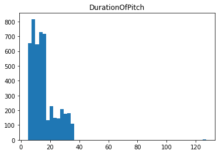

```
0
```

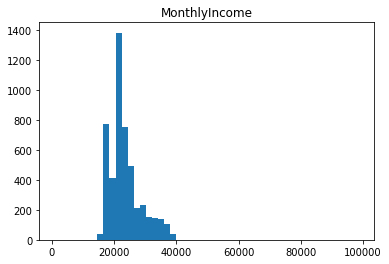

```
0
```

```python
cols_to_log = ['DurationOfPitch','MonthlyIncome']
for colname in cols_to_log:
    plt.hist(data[colname], bins=50)
    plt.title(colname)
    plt.show()
    print(np.sum(data[colname] <= 0))
```

- The features like DurationOfPitch and MonthlyIncome look skewed. We can apply log transformation to make it more uniformly distributed.

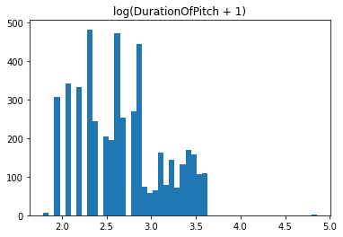

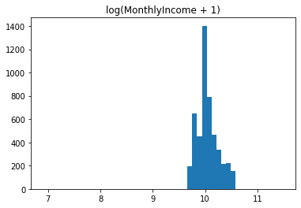

```python
plt.hist(np.log(data['DurationOfPitch'] + 1), 50)
plt.title('log(DurationOfPitch + 1)')
plt.show()
plt.hist(np.log(data['MonthlyIncome'] + 1), 50)
plt.title('log(MonthlyIncome + 1)')
plt.show()
```

```python
for colname in cols_to_log:
    data[colname + '_log'] = np.log(data[colname] + 1)
#data.drop(cols_to_log, axis=1, inplace=True)
```

```python
data.sample(10)
```

|  | ProdTaken | Age | TypeofContact | CityTier | DurationOfPitch | Occupation | Gender | NumberOfPersonVisiting | NumberOfFollowups | ProductPitched | ... | MaritalStatus | NumberOfTrips | Passport | PitchSatisfactionScore | OwnCar | NumberOfChildrenVisiting | Designation | MonthlyIncome | DurationOfPitch_log | MonthlyIncome_log |
| --- | --- | --- | --- | --- | --- | --- | --- | --- | --- | --- | --- | --- | --- | --- | --- | --- | --- | --- | --- | --- | --- |
| 2203 | 0 | 26.0 | Self Enquiry | 1 | 8.0 | Small Business | Male | 2 | 1.0 | Deluxe | ... | Married | 2.000000 | 0 | 3 | 1 | 1.000000 | Manager | 20472.0 | 2.197225 | 9.926862 |
| 3697 | 0 | 34.0 | Company Invited | 3 | 9.0 | Small Business | Female | 4 | 4.0 | Deluxe | ... | Unmarried | 2.000000 | 0 | 1 | 0 | 1.000000 | Manager | 23825.0 | 2.302585 | 10.078533 |
| 4738 | 0 | 43.0 | Self Enquiry | 1 | 36.0 | Small Business | Male | 3 | 6.0 | Deluxe | ... | Unmarried | 6.000000 | 0 | 3 | 1 | 2.000000 | Manager | 22950.0 | 3.610918 | 10.041117 |
| 886 | 0 | 36.0 | Self Enquiry | 1 | 6.0 | Small Business | Male | 3 | 3.0 | Basic | ... | Divorced | 1.000000 | 1 | 4 | 1 | 2.000000 | Executive | 18579.0 | 1.945910 | 9.829841 |
| 2348 | 0 | 42.0 | Company Invited | 2 | 8.0 | Small Business | Male | 3 | 1.0 | Deluxe | ... | Married | 1.000000 | 0 | 1 | 1 | 1.000000 | Manager | 21272.0 | 2.197225 | 9.965194 |
| 2332 | 0 | 44.0 | Company Invited | 1 | 23.0 | Salaried | Male | 3 | 5.0 | Basic | ... | Single | 3.000000 | 0 | 4 | 1 | 1.000000 | Executive | 17290.0 | 3.178054 | 9.757941 |
| 2020 | 0 | 23.0 | Self Enquiry | 1 | 15.0 | Small Business | Male | 2 | 3.0 | Basic | ... | Married | 2.000000 | 0 | 3 | 1 | 0.000000 | Executive | 17500.0 | 2.772589 | 9.770013 |
| 4190 | 0 | 36.0 | Self Enquiry | 1 | 29.0 | Salaried | Female | 4 | 2.0 | Standard | ... | Married | 2.000000 | 0 | 5 | 1 | 3.000000 | Senior Manager | 30674.0 | 3.401197 | 10.331203 |
| 4783 | 0 | 47.0 | Self Enquiry | 1 | 22.0 | Salaried | Male | 3 | 4.0 | King | ... | Married | 3.236521 | 0 | 3 | 1 | 2.000000 | VP | 37759.0 | 3.135494 | 10.539006 |
| 4506 | 0 | 48.0 | Self Enquiry | 1 | 9.0 | Salaried | Female | 3 | 4.0 | Super Deluxe | ... | Married | 3.000000 | 1 | 4 | 1 | 1.187267 | AVP | 35430.0 | 2.302585 | 10.475342 |

10 rows × 21 columns

## Visualization

### Univariate Analysis

```python
# function to plot a boxplot and a histogram along the same scale.


def histogram_boxplot(data, feature, figsize=(12, 7), kde=False, bins=None):
    """
    Boxplot and histogram combined

    data: dataframe
    feature: dataframe column
    figsize: size of figure (default (12,7))
    kde: whether to show the density curve (default False)
    bins: number of bins for histogram (default None)
    """
    f2, (ax_box2, ax_hist2) = plt.subplots(
        nrows=2,  # Number of rows of the subplot grid= 2
        sharex=True,  # x-axis will be shared among all subplots
        gridspec_kw={"height_ratios": (0.25, 0.75)},
        figsize=figsize,
    )  # creating the 2 subplots
    sns.boxplot(
        data=data, x=feature, ax=ax_box2, showmeans=True, color="violet"
    )  # boxplot will be created and a star will indicate the mean value of the column
    sns.histplot(
        data=data, x=feature, kde=kde, ax=ax_hist2, bins=bins, palette="winter"
    ) if bins else sns.histplot(
        data=data, x=feature, kde=kde, ax=ax_hist2
    )  # For histogram
    ax_hist2.axvline(
        data[feature].mean(), color="green", linestyle="--"
    )  # Add mean to the histogram
    ax_hist2.axvline(
        data[feature].median(), color="black", linestyle="-"
    )  # Add median to the histogram
```

```python
# function to create labeled barplots


def labeled_barplot(data, feature, perc=False, n=None):
    """
    Barplot with percentage at the top

    data: dataframe
    feature: dataframe column
    perc: whether to display percentages instead of count (default is False)
    n: displays the top n category levels (default is None, i.e., display all levels)
    """

    total = len(data[feature])  # length of the column
    count = data[feature].nunique()
    if n is None:
        plt.figure(figsize=(count + 2, 6))
    else:
        plt.figure(figsize=(n + 2, 6))

    plt.xticks(rotation=90, fontsize=15)
    ax = sns.countplot(
        data=data,
        x=feature,
        palette="Paired",
        order=data[feature].value_counts().index[:n].sort_values(),
    )

    for p in ax.patches:
        if perc == True:
            label = "{:.1f}%".format(
                100 * p.get_height() / total
            )  # percentage of each class of the category
        else:
            label = p.get_height()  # count of each level of the category

        x = p.get_x() + p.get_width() / 2  # width of the plot
        y = p.get_height()  # height of the plot

        ax.annotate(
            label,
            (x, y),
            ha="center",
            va="center",
            size=12,
            xytext=(0, 5),
            textcoords="offset points",
        )  # annotate the percentage

    plt.show()  # show the plot
```

```
array([[<AxesSubplot:title={'center':'NumberOfPersonVisiting'}>,
        <AxesSubplot:title={'center':'NumberOfFollowups'}>],
       [<AxesSubplot:title={'center':'PreferredPropertyStar'}>,
        <AxesSubplot:title={'center':'PitchSatisfactionScore'}>],
       [<AxesSubplot:title={'center':'NumberOfChildrenVisiting'}>,
        <AxesSubplot:>]], dtype=object)
```

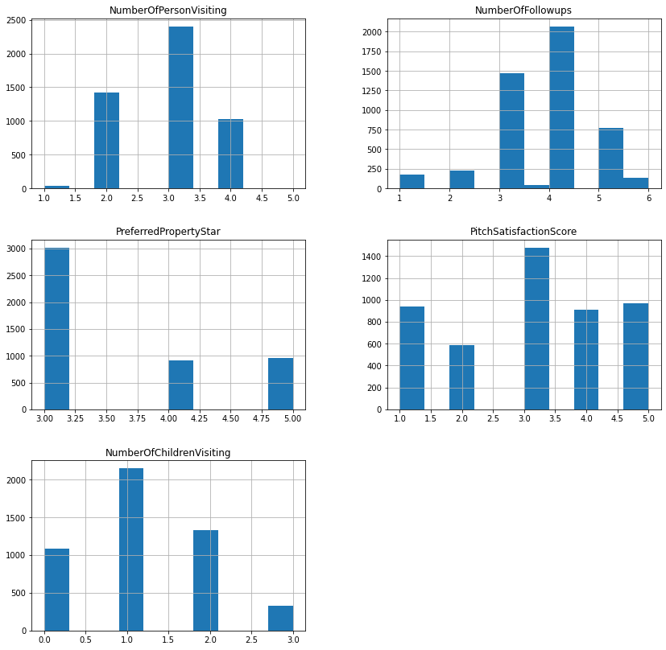

```python
features = ['NumberOfPersonVisiting','NumberOfFollowups','PreferredPropertyStar','PitchSatisfactionScore','NumberOfChildrenVisiting']
# creating histograms
data[features].hist(figsize=(14, 14))
plt.show()
```

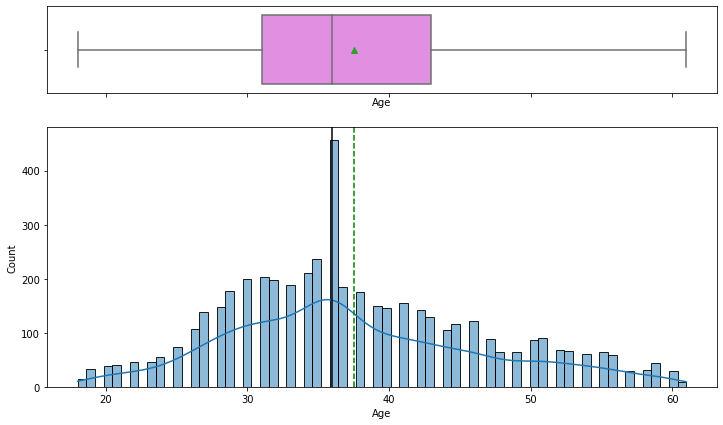

```python
histogram_boxplot(data,'Age',kde=True, bins=70)
```

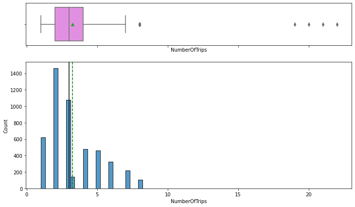

```python
histogram_boxplot(data,'NumberOfTrips', bins=70)
```

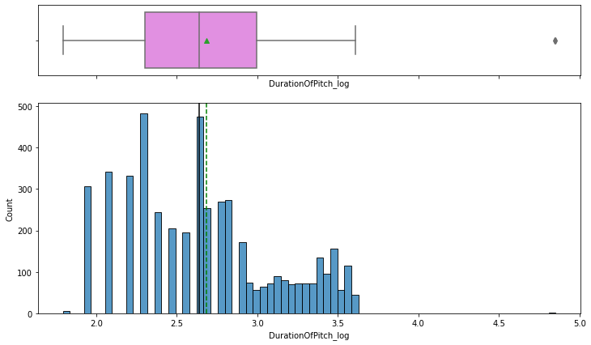

```python
histogram_boxplot(data,'DurationOfPitch_log', bins=70)
```

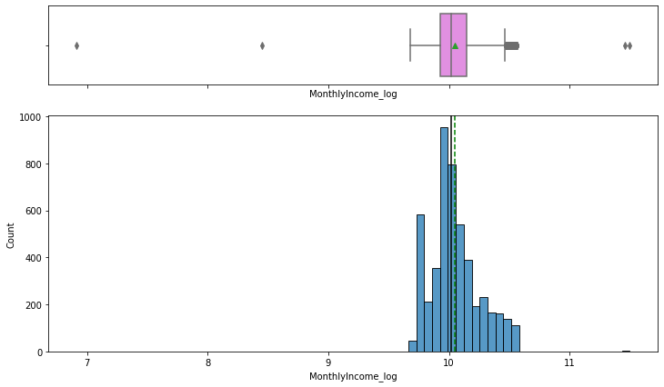

```python
histogram_boxplot(data,'MonthlyIncome_log', bins=70)
```

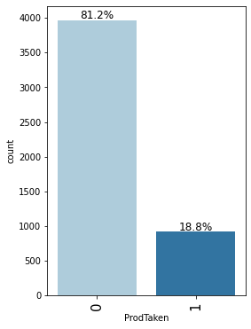

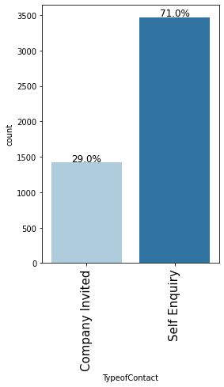

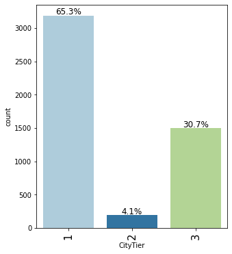

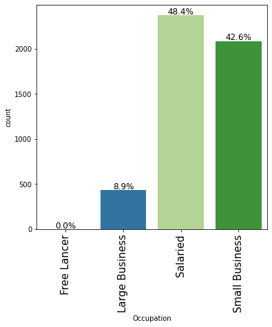

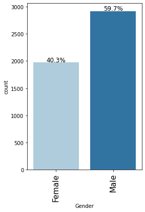

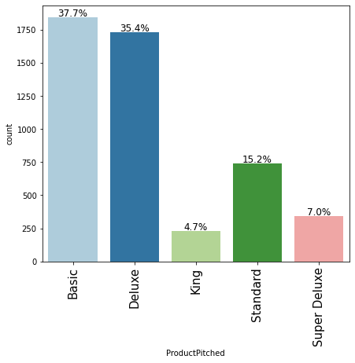

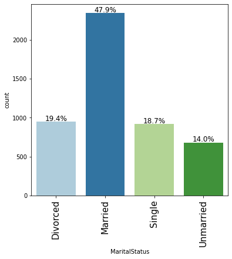

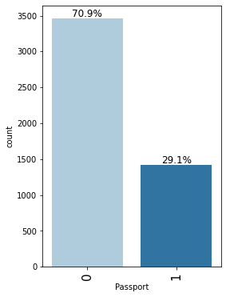

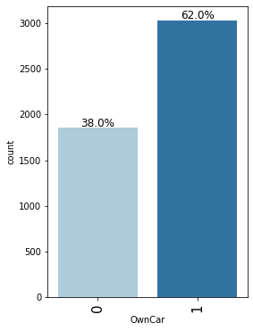

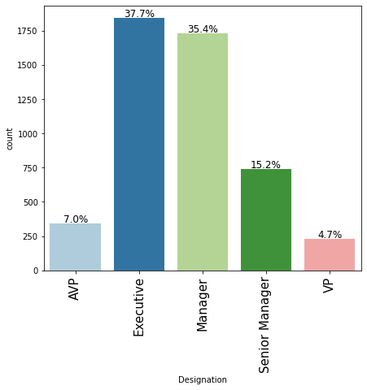

```python
cat_features = ['ProdTaken','TypeofContact', 'CityTier','Occupation', 'Gender',
            'ProductPitched', 'MaritalStatus', 'Passport', 'OwnCar','Designation']
for feature in cat_features:
    labeled_barplot(data, feature, perc=True)
```

### Bivariate Analysis

```python
def stacked_barplot(data, predictor, target):
    """
    Print the category counts and plot a stacked bar chart

    data: dataframe
    predictor: independent variable
    target: target variable
    """
    count = data[predictor].nunique()
    sorter = data[target].value_counts().index[-1]
    tab1 = pd.crosstab(data[predictor], data[target], margins=True).sort_values(
        by=sorter, ascending=False
    )
    print(tab1)
    print("-" * 120)
    tab = pd.crosstab(data[predictor], data[target], normalize="index").sort_values(
        by=sorter, ascending=False
    )
    tab.plot(kind="bar", stacked=True, figsize=(count + 5, 6))
    plt.legend(
        loc="lower left", frameon=False,
    )
    plt.legend(loc="upper left", bbox_to_anchor=(1, 1))
    plt.show()
```

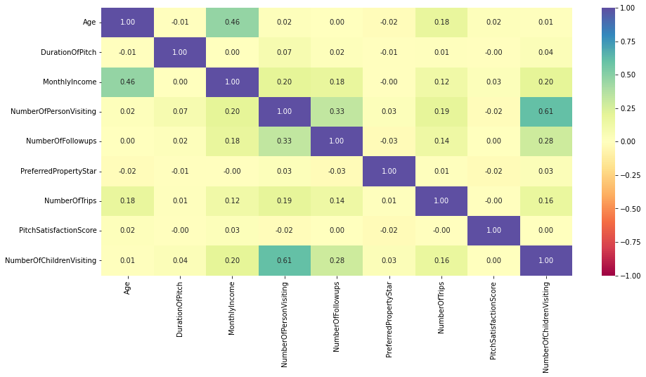

```python
corr_cols = [
'Age',
'DurationOfPitch',
'MonthlyIncome',
'NumberOfPersonVisiting',
'NumberOfFollowups',
'PreferredPropertyStar',
'NumberOfTrips',
'PitchSatisfactionScore',
'NumberOfChildrenVisiting'
]

plt.figure(figsize=(15, 7))
sns.heatmap(
    data[corr_cols].corr(), annot=True, vmin=-1, vmax=1, fmt=".2f", cmap="Spectral"
)
plt.show()
```

```
ProdTaken           0    1   All
TypeofContact
All              3968  920  4888
Self Enquiry     2859  610  3469
Company Invited  1109  310  1419
------------------------------------------------------------------------------------------------------------------------
```

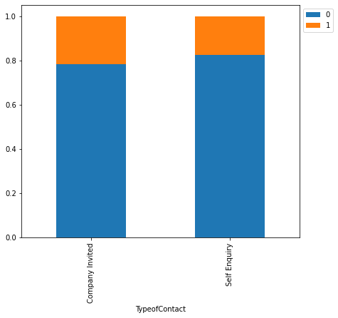

```
ProdTaken     0    1   All
CityTier
All        3968  920  4888
1          2670  520  3190
3          1146  354  1500
2           152   46   198
------------------------------------------------------------------------------------------------------------------------
```

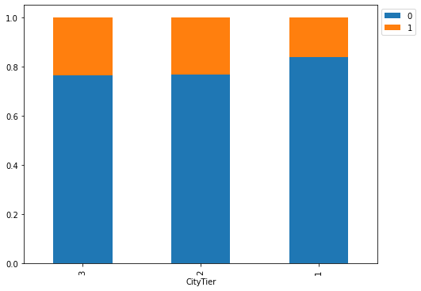

```
ProdTaken          0    1   All
Occupation
All             3968  920  4888
Salaried        1954  414  2368
Small Business  1700  384  2084
Large Business   314  120   434
Free Lancer        0    2     2
------------------------------------------------------------------------------------------------------------------------
```

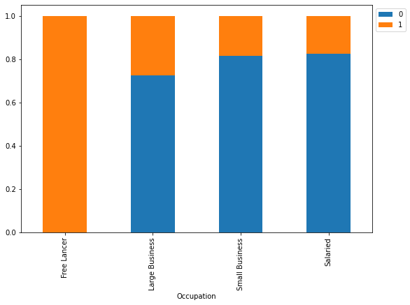

```
ProdTaken     0    1   All
Gender
All        3968  920  4888
Male       2338  578  2916
Female     1630  342  1972
------------------------------------------------------------------------------------------------------------------------
```

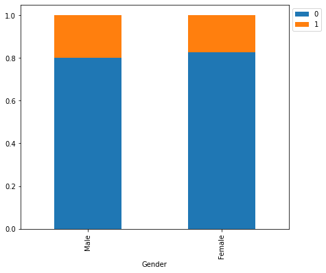

```
ProdTaken          0    1   All
ProductPitched
All             3968  920  4888
Basic           1290  552  1842
Deluxe          1528  204  1732
Standard         618  124   742
King             210   20   230
Super Deluxe     322   20   342
------------------------------------------------------------------------------------------------------------------------
```

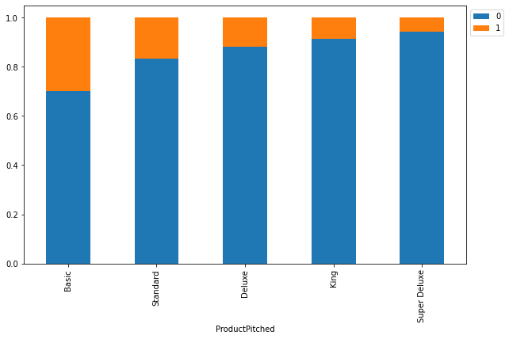

```
ProdTaken         0    1   All
MaritalStatus
All            3968  920  4888
Married        2014  326  2340
Single          612  304   916
Unmarried       516  166   682
Divorced        826  124   950
------------------------------------------------------------------------------------------------------------------------
```

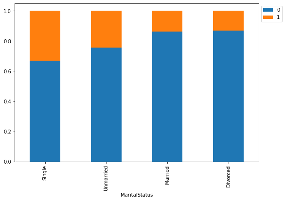

```
ProdTaken     0    1   All
Passport
All        3968  920  4888
1           928  494  1422
0          3040  426  3466
------------------------------------------------------------------------------------------------------------------------
```

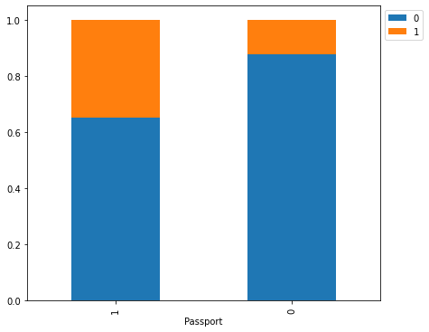

```
ProdTaken     0    1   All
OwnCar
All        3968  920  4888
1          2472  560  3032
0          1496  360  1856
------------------------------------------------------------------------------------------------------------------------
```

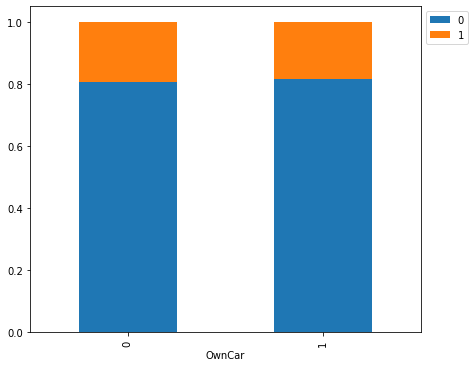

```
ProdTaken          0    1   All
Designation
All             3968  920  4888
Executive       1290  552  1842
Manager         1528  204  1732
Senior Manager   618  124   742
AVP              322   20   342
VP               210   20   230
------------------------------------------------------------------------------------------------------------------------
```

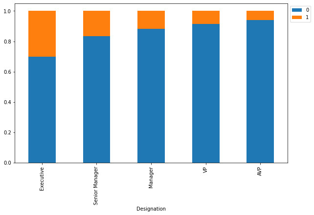

```python
pred_features = ['TypeofContact', 'CityTier','Occupation', 'Gender',
            'ProductPitched', 'MaritalStatus', 'Passport', 'OwnCar','Designation']
target = 'ProdTaken'
for predictor in pred_features:
    stacked_barplot(data, predictor, target)
```